# Lab 03: Ridge Regression & the basics of Lasso

Required packages:

- `ISLR`: for data
- `glmnet`: for Ridge.
- `foreach`: for Loops.
- `kableExtra`: for tables.

Clear the workspace

```r
rm(list=ls())
```

# Load the data

```r
library(ISLR)
?Hitters
names(Hitters)
```

```
##  [1] "AtBat"     "Hits"      "HmRun"     "Runs"      "RBI"       "Walks"
##  [7] "Years"     "CAtBat"    "CHits"     "CHmRun"    "CRuns"     "CRBI"
## [13] "CWalks"    "League"    "Division"  "PutOuts"   "Assists"   "Errors"
## [19] "Salary"    "NewLeague"
```

Drop observations with missing values:

```r
Hitters<-na.omit(Hitters)
```

We want to predict the Salary using the performance stats:

```r
x<-model.matrix(Salary~.,Hitters)[,-1]
y<-Hitters$Salary
```

- `model.matrix(Salary~.,Hitters)` creates a model to explain Salary in data Hitters using all the variables.
- It also transforms **qualitative variables into dummies**.
- The option `[,-1]` drops the intercept (otherwise a column of ones is added to `x`).

```r
dim(x)
```

```
## [1] 263  19
```

There are:

- `n=263` observations.
- 19 regressors.

# Ridge regression

```r
suppressMessages(library(glmnet))
```

- The function `glmnet(x,y,alpha=0,lambda=10)` runs the ridge regression with a regularization parameter $\lambda=10$.
- `alpha=0` instructs `glmnet()` to run Ridge.
- With `alpha=1`, it would run Lasso instead.
- By default, the regressors are standardized: each regressor $j$ has a zero average and a unit sample variance: $\sum_{i=1}^n X_{i,j}=0$ and $n^{-1}\sum_{i=1}^n X^2_{i,j}=1$.
  - If $Z_{i,j}$ is the original variable, $\bar Z_j=n^{-1}\sum_{i=1}^n Z_{i,j}$, $\hat\sigma^2_j=n^{-1}\sum_{i=1}^n (Z_{i,j}-\bar Z_j)^2$, then
    $$X_{i,j}=\frac{Z_{i,j}-\bar Z_j}{\hat\sigma_j}$$
- To prevent automatic standardization, use the option `standardize = FALSE`.
- We can access the coefficients using `Ridge10$beta` or `coef(Ridge10)`.
  - `coef()` also includes the intercept.

```r
Ridge10<-glmnet(x,y,alpha=0,lambda=10)
cbind(Ridge10$beta,coef(Ridge10)[-1])
```

```
## 19 x 2 sparse Matrix of class "dgCMatrix"
##                       s0
## AtBat        -1.20789023   -1.20789023
## Hits          4.29056019    4.29056019
## HmRun        -0.50021742   -0.50021742
## Runs          0.46290656    0.46290656
## RBI           0.40200051    0.40200051
## Walks         4.40442253    4.40442253
## Years       -10.84634568  -10.84634568
## CAtBat       -0.02213352   -0.02213352
## CHits         0.16694987    0.16694987
## CHmRun        0.69948666    0.69948666
## CRuns         0.46905139    0.46905139
## CRBI          0.32970628    0.32970628
## CWalks       -0.46021788   -0.46021788
## LeagueN      58.99724234   58.99724234
## DivisionW  -124.23426731 -124.23426731
## PutOuts       0.27419765    0.27419765
## Assists       0.23684897    0.23684897
## Errors       -3.85301716   -3.85301716
## NewLeagueN  -25.47617851  -25.47617851
```

- The results using `$beta` or `coef()` are the same.

##### Create a grid of values for $\lambda$

```r
grid=seq(from=0.01,to=20000,length=100)
grid
```

```
##   [1]     0.0100   202.0301   404.0502   606.0703   808.0904  1010.1105
##   [7]  1212.1306  1414.1507  1616.1708  1818.1909  2020.2110  2222.2311
##  [13]  2424.2512  2626.2713  2828.2914  3030.3115  3232.3316  3434.3517
##  [19]  3636.3718  3838.3919  4040.4120  4242.4321  4444.4522  4646.4723
##  [25]  4848.4924  5050.5125  5252.5326  5454.5527  5656.5728  5858.5929
##  [31]  6060.6130  6262.6331  6464.6532  6666.6733  6868.6934  7070.7135
##  [37]  7272.7336  7474.7537  7676.7738  7878.7939  8080.8140  8282.8341
##  [43]  8484.8542  8686.8743  8888.8944  9090.9145  9292.9346  9494.9547
##  [49]  9696.9748  9898.9949 10101.0151 10303.0352 10505.0553 10707.0754
##  [55] 10909.0955 11111.1156 11313.1357 11515.1558 11717.1759 11919.1960
##  [61] 12121.2161 12323.2362 12525.2563 12727.2764 12929.2965 13131.3166
##  [67] 13333.3367 13535.3568 13737.3769 13939.3970 14141.4171 14343.4372
##  [73] 14545.4573 14747.4774 14949.4975 15151.5176 15353.5377 15555.5578
##  [79] 15757.5779 15959.5980 16161.6181 16363.6382 16565.6583 16767.6784
##  [85] 16969.6985 17171.7186 17373.7387 17575.7588 17777.7789 17979.7990
##  [91] 18181.8191 18383.8392 18585.8593 18787.8794 18989.8995 19191.9196
##  [97] 19393.9397 19595.9598 19797.9799 20000.0000
```

### Let’s run Ridge!

```r
ridge.mod<-glmnet(x,y,alpha=0,lambda=grid)
```

- R creates an object `ridge.mod` that contains the results.
- Let’s see what’s inside:

```r
names(ridge.mod)
```

```
##  [1] "a0"        "beta"      "df"        "dim"       "lambda"    "dev.ratio"
##  [7] "nulldev"   "npasses"   "jerr"      "offset"    "call"      "nobs"
```

- `beta`: estimated coefficients.
  - To access use `ridge.mod$beta`.
  - Also `coef(ridge.mod)`.
- `df`: degrees of freedom (the number of regressors)
- `nulldev`: the sample variation of `y`: $\sum_{i=1}^n(Y_i-\bar Y)^2$.
- `dev.ratio`: 1-SSR/nulldev
- To get SSR: `deviance(ridge.mod)`.

There is one set of coefficients for each value of `lambda`:

```r
dim(coef(ridge.mod))
```

```
## [1]  20 100
```

We have 20 coefficients (including the intercept) corresponding to the 100 values of $\lambda$.

##### Compare coefficients for smaller and larger values of $\lambda$

```r
ridge.mod$lambda
```

```
##   [1] 20000.0000 19797.9799 19595.9598 19393.9397 19191.9196 18989.8995
##   [7] 18787.8794 18585.8593 18383.8392 18181.8191 17979.7990 17777.7789
##  [13] 17575.7588 17373.7387 17171.7186 16969.6985 16767.6784 16565.6583
##  [19] 16363.6382 16161.6181 15959.5980 15757.5779 15555.5578 15353.5377
##  [25] 15151.5176 14949.4975 14747.4774 14545.4573 14343.4372 14141.4171
##  [31] 13939.3970 13737.3769 13535.3568 13333.3367 13131.3166 12929.2965
##  [37] 12727.2764 12525.2563 12323.2362 12121.2161 11919.1960 11717.1759
##  [43] 11515.1558 11313.1357 11111.1156 10909.0955 10707.0754 10505.0553
##  [49] 10303.0352 10101.0151  9898.9949  9696.9748  9494.9547  9292.9346
##  [55]  9090.9145  8888.8944  8686.8743  8484.8542  8282.8341  8080.8140
##  [61]  7878.7939  7676.7738  7474.7537  7272.7336  7070.7135  6868.6934
##  [67]  6666.6733  6464.6532  6262.6331  6060.6130  5858.5929  5656.5728
##  [73]  5454.5527  5252.5326  5050.5125  4848.4924  4646.4723  4444.4522
##  [79]  4242.4321  4040.4120  3838.3919  3636.3718  3434.3517  3232.3316
##  [85]  3030.3115  2828.2914  2626.2713  2424.2512  2222.2311  2020.2110
##  [91]  1818.1909  1616.1708  1414.1507  1212.1306  1010.1105   808.0904
##  [97]   606.0703   404.0502   202.0301     0.0100
```

```r
library(kableExtra)

lambda_ind_small=99
lambda_ind_large=2

cbind(ridge.mod$beta[,lambda_ind_small],ridge.mod$beta[,lambda_ind_large]) %>%
  kable(digits=3,
        caption="Estimated Ridge coefficients for small and large penalty $\\lambda$",
        col.names=c(paste0("$\\lambda=$ ",round(ridge.mod$lambda[lambda_ind_small],digits=2)),paste0("$\\lambda=$ ",round(ridge.mod$lambda[lambda_ind_large],digits=2)))
        ) %>%
  kable_classic(full_width = F, html_font = "Cambria")
```

Estimated Ridge coefficients for small and large penalty $\lambda$

|  | $\lambda=$ 202.03 | $\lambda=$ 19797.98 |
| --- | --- | --- |
| AtBat | 0.025 | 0.024 |
| Hits | 1.029 | 0.087 |
| HmRun | 0.100 | 0.340 |
| Runs | 1.119 | 0.147 |
| RBI | 0.874 | 0.153 |
| Walks | 1.823 | 0.183 |
| Years | 0.051 | 0.720 |
| CAtBat | 0.011 | 0.002 |
| CHits | 0.065 | 0.007 |
| CHmRun | 0.452 | 0.056 |
| CRuns | 0.130 | 0.015 |
| CRBI | 0.139 | 0.015 |
| CWalks | 0.027 | 0.016 |
| LeagueN | 27.763 | -0.069 |
| DivisionW | -92.875 | -3.736 |
| PutOuts | 0.194 | 0.010 |
| Assists | 0.044 | 0.002 |
| Errors | -1.866 | -0.010 |
| NewLeagueN | 6.923 | 0.096 |

# Out-of-sample predictions

Next, we’ll consider out-of-sample prediction of the salary.

### Data spliting

We split our data set into:

- Training/Estimation sample.
- Test/Validation sample.

We use the `sample()` function which randomly draws from a list:

```r
sample(seq(1:10),5)
```

```
## [1]  9  5  4  8 10
```

Let’s split our data into two equal size sub-samples:

The total number of observations:

```r
nrow(x)
```

```
## [1] 263
```

```r
set.seed(1,sample.kind="Rejection")
train<-sample(1:nrow(x),nrow(x)/2)
test<-(-train)
y.test<-y[test]
```

- The vector `train` includes observation numbers put into the training sample.
- `x` for the training sample is `x[train,]`.
- `x` for the test sample is `x[-train,]`.

### Estimate the model on the training data

```r
ridge.mod<-glmnet(x[train,],y[train],alpha=0,lambda=grid)
```

### Construct out-of-sample predictions

- use `predict(model,...)`.
- use `newx=x[test,]` to supply the out of sample values of the predictors.

```r
ridge.pred<-predict(ridge.mod,newx=x[test,],exact=T,x=x[train,],y=y[train])
```

- prediction for each observation (rows)

```r
nrow(ridge.pred)
```

```
## [1] 132
```

```r
head(ridge.pred[,1],10)
```

```
##      -Alvin Davis     -Andre Dawson -Andres Galarraga  -Alfredo Griffin
##          543.9470          602.8801          500.7614          550.8382
##        -Al Newman  -Argenis Salazar    -Andres Thomas   -Andre Thornton
##          475.5746          476.8017          481.0847          608.9633
##    -Alan Trammell     -Alex Trevino
##          592.9548          503.0376
```

- different predictions for different values of `lambda` (columns)

```r
ncol(ridge.pred)
```

```
## [1] 100
```

```r
head(ridge.pred[1,],10)
```

```
##       s0       s1       s2       s3       s4       s5       s6       s7
## 543.9470 544.0532 544.1617 544.2720 544.3844 544.4988 544.6154 544.7341
##       s8       s9
## 544.8550 544.9783
```

### Out-of-sample fit (MSE) for each `lambda` value

```r
library(foreach)
Fit<-foreach(j=1:100, .combine='cbind') %do% {
  mean((ridge.pred[,j]-y.test)^2)
}
```

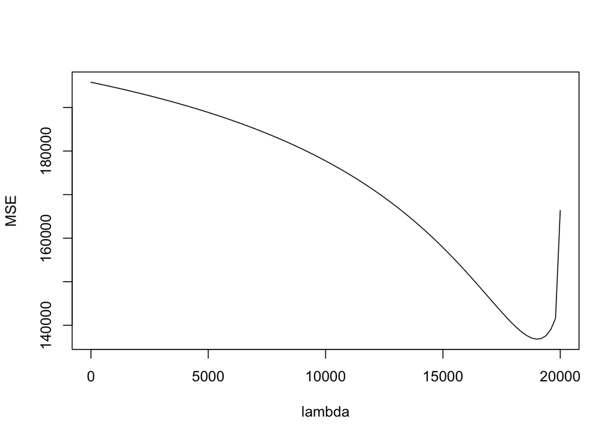

```r
plot(grid,Fit,type="l", xlab="lambda", ylab="MSE")
```

One can see that there is a best `lambda` value! Let’s find it:

```r
best_ind_lambda<-which.min(Fit)
sprintf("The index of the best lambda is %g", best_ind_lambda)
```

```
## [1] "The index of the best lambda is 95"
```

```r
best_lambda<-grid[best_ind_lambda]
sprintf("The best lambda is %g", best_lambda)
```

```
## [1] "The best lambda is 18989.9"
```

```r
Ridge_best_Fit<-Fit[best_ind_lambda]

sprintf("The corresponding best fit (MSE) is %g",Ridge_best_Fit)
```

```
## [1] "The corresponding best fit (MSE) is 136811"
```

- This is the first best choice of `lambda` for Ridge, but it would be infeasible in practice: the true outcome out of sample is unknown!

### Let’s compare with OLS prediction

- We can construct OLS by setting `lambda=0`

```r
lm.mod<-glmnet(x[train,],y[train],alpha=0,lambda=0,thresh = 1e-20)
```

Let’s compare the coefficients:

```r
round(cbind(coef(lm.mod),coef(lm(y[train]~x[train,]))),digits=4)
```

```
## 20 x 2 sparse Matrix of class "dgCMatrix"
##                    s0
## (Intercept)  274.0145  274.0145
## AtBat         -0.3521   -0.3521
## Hits          -1.6377   -1.6377
## HmRun          5.8145    5.8145
## Runs           1.5424    1.5424
## RBI            1.1243    1.1243
## Walks          3.7287    3.7287
## Years        -16.3773  -16.3773
## CAtBat        -0.6412   -0.6412
## CHits          3.1632    3.1632
## CHmRun         3.4008    3.4008
## CRuns         -0.9739   -0.9739
## CRBI          -0.6005   -0.6005
## CWalks         0.3379    0.3379
## LeagueN      119.1486  119.1486
## DivisionW   -144.0831 -144.0831
## PutOuts        0.1976    0.1976
## Assists        0.6804    0.6804
## Errors        -4.7128   -4.7128
## NewLeagueN   -71.0951  -71.0951
```

OLS out of sample fit:

```r
lm.pred<-predict(lm.mod,newx=x[test,],exact=T)
lm.Fit<- mean((lm.pred-y.test)^2)
sprintf("The OLS fit is        %g",lm.Fit)
```

```
## [1] "The OLS fit is        168593"
```

```r
sprintf("The Ridge best fit is %g",Ridge_best_Fit)
```

```
## [1] "The Ridge best fit is 136811"
```

```r
cat("Ridge outperforms OLS by ",(lm.Fit/Fit[best_ind_lambda]-1)*100, "%")
```

```
## Ridge outperforms OLS by  23.2311 %
```

# Conclusions

- Ridge can be a superior (to OLS) forecasting tool.
- The choice of penalty is important.
- Ridge does not select regressors! All regressors have non-zero coefficients:

```r
coef(ridge.mod)[,best_ind_lambda]
```

```
##  (Intercept)        AtBat         Hits        HmRun         Runs          RBI
## 119.85667940   0.07515337   0.30143302   2.06397392   0.64487799   0.68843160
##        Walks        Years       CAtBat        CHits       CHmRun        CRuns
##   1.29185721   1.76738592   0.01262676   0.05236788   0.48058551   0.10482481
##         CRBI       CWalks      LeagueN    DivisionW      PutOuts      Assists
##   0.11848357   0.14105640  18.95075523 -49.74090208   0.06386002   0.02796939
##       Errors   NewLeagueN
##  -0.10500699  12.22043342
```

# Cross validation (CV)

- In practice we do not see out of sample outcomes.
- We cannot do what we did above: selected the best `lambda` by comparing with the true out of sample values.
- CV creates “pseudo” out of sample outcomes by excluding some observations when fitting the model.
  - Split data randomly into several “folds”.
  - Pick `lambda`.
  - Estimate by excluding one of the folds.
  - Construct predictions for the excluded fold.
  - Evaluate the fit on the excluded fold.
  - Repeat by excluding different folds.
  - Average the fit across the folds.
  - Repeat for all candidate values of `lambda`.
  - Choose `lambda` that results in the smallest average out of sample fit.
- For `glmnet()`, CV is implemented as `cv.glmnet()`.
- `nfolds=` sets the number of folds.

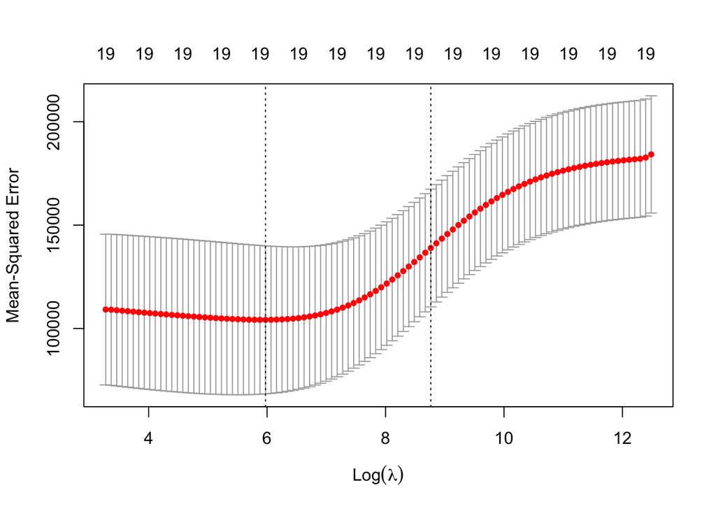

```r
set.seed(10,sample.kind="Rejection")
cv.ridge<-cv.glmnet(x[train,],y[train],alpha=0,nfolds=10)
plot(cv.ridge)
```

- The curves are the mean cross validated error plus/minus one standard error of CV
- CV-best value of $\lambda$

```r
cv.ridge$lambda.min
```

```
## [1] 392.7679
```

##### The one-standard-error rule:

- A larger penalty `lambda` that results in the measure of fit within one standard error of the “best” fit.
- Slightly more regularization.
- Approximately the same fit (within 1 CV standard error)

```r
cv.ridge$lambda.1se
```

```
## [1] 6401.138
```

### Out-of-sample prediction with cross validated penalty

```r
ridge.pred=predict(cv.ridge,s=cv.ridge$lambda.min,newx=x[test,],exact=T,x=x[train,],y=y[train])

Ridge_CV_fit<-mean((ridge.pred-y.test)^2)
sprintf("The Ridge fit using the best CV penalty is %g",Ridge_CV_fit)
```

```
## [1] "The Ridge fit using the best CV penalty is 139156"
```

```r
cat("With the best CV penalty, Ridge outperforms OLS by",(lm.Fit/Ridge_CV_fit-1)*100,"%")
```

```
## With the best CV penalty, Ridge outperforms OLS by 21.15458 %
```

##### To see the corresponding Ridge coefficients

```r
coef(cv.ridge,s=cv.ridge$lambda.min)
```

```
## 20 x 1 sparse Matrix of class "dgCMatrix"
##                       s1
## (Intercept)  69.24945953
## AtBat         0.04655742
## Hits          0.31458288
## HmRun         2.53803759
## Runs          0.68579392
## RBI           0.73670528
## Walks         1.83003906
## Years        -0.88078481
## CAtBat        0.01320582
## CHits         0.06458870
## CHmRun        0.64594507
## CRuns         0.12645156
## CRBI          0.15453813
## CWalks        0.17116968
## LeagueN      32.45687911
## DivisionW   -81.17837286
## PutOuts       0.09419727
## Assists       0.06964780
## Errors       -0.37701793
## NewLeagueN   18.19419147
```

**NO Selection**!!!: all are non-zeros.

- CV choice is feasible in practice.
- CV produced fit is slightly worse than the infeasible first best, but close.

# Lasso

### Let’s run Lasso!

- specify `alpha=1` to instruct `glmnet()` to run lasso.

```r
lasso.mod=glmnet(x,y,alpha=1)
names(lasso.mod)
```

```
##  [1] "a0"        "beta"      "df"        "dim"       "lambda"    "dev.ratio"
##  [7] "nulldev"   "npasses"   "jerr"      "offset"    "call"      "nobs"
```

- We let `glmnet()` to chose the values of `lambda`.
- The values considered:

```r
length(lasso.mod$lambda)
```

```
## [1] 80
```

```r
lasso.mod$lambda
```

```
##  [1] 255.2820965 232.6035386 211.9396813 193.1115442 175.9560468 160.3245966
##  [7] 146.0818013 133.1042967 121.2796778 110.5055255 100.6885192  91.7436287
## [13]  83.5933775  76.1671723  69.4006906  63.2353245  57.6176726  52.4990774
## [19]  47.8352040  43.5856563  39.7136268  36.1855776  32.9709506  30.0419022
## [25]  27.3730624  24.9413150  22.7255973  20.7067179  18.8671902  17.1910810
## [31]  15.6638727  14.2723374  13.0044223  11.8491453  10.7964999   9.8373686
## [37]   8.9634439   8.1671562   7.4416086   6.7805166   6.1781542   5.6293040
## [43]   5.1292121   4.6735471   4.2583620   3.8800609   3.5353670   3.2212947
## [49]   2.9351238   2.6743755   2.4367913   2.2203135   2.0230670   1.8433433
## [55]   1.6795857   1.5303760   1.3944216   1.2705450   1.1576733   1.0548288
## [61]   0.9611207   0.8757374   0.7979393   0.7270526   0.6624632   0.6036118
## [67]   0.5499886   0.5011291   0.4566102   0.4160462   0.3790858   0.3454089
## [73]   0.3147237   0.2867645   0.2612891   0.2380769   0.2169268   0.1976557
## [79]   0.1800965   0.1640972
```

### Let’s compare the coefficients for different `lambda`’s:

```r
lambda_ind_small=60
lambda_ind_large=10

cbind(lasso.mod$beta[,lambda_ind_small],lasso.mod$beta[,lambda_ind_large]) %>%
  kable(digits=2,
        caption="Estimated Lasso coefficients for small and large penalty $\\lambda$",
        col.names=c(paste0("$\\lambda=$ ",round(lasso.mod$lambda[lambda_ind_small],digits=2)),paste0("$\\lambda=$ ",round(lasso.mod$lambda[lambda_ind_large],digits=2)))
        ) %>%
  kable_classic(full_width = F, html_font = "Cambria")
```

Estimated Lasso coefficients for small and large penalty $\lambda$

|  | $\lambda=$ 1.05 | $\lambda=$ 110.51 |
| --- | --- | --- |
| AtBat | -1.92 | 0.00 |
| Hits | 6.73 | 1.00 |
| HmRun | 1.18 | 0.00 |
| Runs | -0.91 | 0.00 |
| RBI | 0.00 | 0.00 |
| Walks | 5.57 | 0.99 |
| Years | -7.88 | 0.00 |
| CAtBat | -0.06 | 0.00 |
| CHits | 0.00 | 0.00 |
| CHmRun | 0.25 | 0.00 |
| CRuns | 1.10 | 0.11 |
| CRBI | 0.56 | 0.29 |
| CWalks | -0.72 | 0.00 |
| LeagueN | 45.71 | 0.00 |
| DivisionW | -116.86 | 0.00 |
| PutOuts | 0.28 | 0.00 |
| Assists | 0.28 | 0.00 |
| Errors | -2.83 | 0.00 |
| NewLeagueN | -9.44 | 0.00 |

- For a larger `lambda`:
  - The coefficients are smaller.
  - More coefficients are shrunk to zero.

# Out of sample with Lasso

### Cross validation

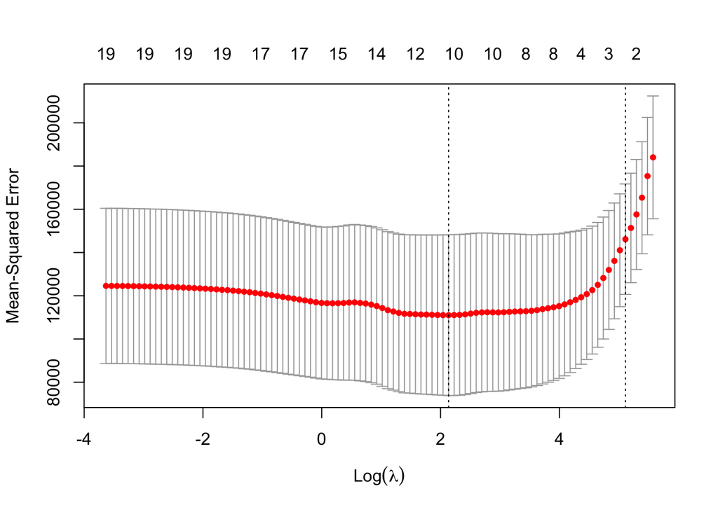

```r
set.seed(10,sample.kind="Rejection")
cv.lasso=cv.glmnet(x[train,],y[train],alpha=1,nfolds=10)
plot(cv.lasso)
```

Best `lambda`:

```r
cv.lasso$lambda.min
```

```
## [1] 8.461927
```

### Out of sample with the CV Lasso penalty

```r
lasso.pred<-predict(cv.lasso,s=cv.lasso$lambda.min,newx=x[test,],exact=T,x=x[train,],y=y[train])
Lasso_CV_fit<-mean((lasso.pred-y.test)^2)
sprintf("The Lasso fit using the cross validated penalty is %g",Lasso_CV_fit)
```

```
## [1] "The Lasso fit using the cross validated penalty is 143808"
```

# Out of sample comparison with Ridge and OLS:

```r
TAB<-cbind((lm.Fit/Lasso_CV_fit-1)*100, (lm.Fit/Ridge_CV_fit-1)*100)

TAB %>%
  kable(digits=2,
        col.names =c("Lasso","Ridge"),
        caption ="Percentage Improvement (%) in the out-of-sample fit relatively to OLS "
        ) %>%
  kable_classic(full_width = F, html_font = "Cambria")
```

Percentage Improvement (%) in the out-of-sample fit relatively to OLS

| Lasso | Ridge |
| --- | --- |
| 17.24 | 21.15 |

```r
coef(cv.lasso,s=cv.lasso$lambda.min)
```

```
## 20 x 1 sparse Matrix of class "dgCMatrix"
##                       s1
## (Intercept)  121.9078065
## AtBat          .
## Hits           .
## HmRun          3.4527540
## Runs           .
## RBI            .
## Walks          4.0095547
## Years        -13.2996313
## CAtBat         .
## CHits          0.2172280
## CHmRun         0.8938979
## CRuns          .
## CRBI           0.3905921
## CWalks         .
## LeagueN       49.0732182
## DivisionW   -136.8585418
## PutOuts        0.1182314
## Assists        0.1424964
## Errors         .
## NewLeagueN     .
```

# Conclusion

- Ridge uses all available variables.
- Ridge can be superior to OLS and Lasso for forecasting/out of sample prediction.
- Ridge does not have the selection properties.
- Lasso selects right-hand side variables.

**Question**: How to select the penalty when the goal is not forecasting but estimation of structural/causal effects?